# CASTfxn Vignette

Erik W. Leppo

2019-01-24

# Introduction

`CASTfxn` was created by Tetra Tech, Inc. for in 2018 to support the Causal Assessment Screening Tool. This tool aides data managers to more quickly analyze large amounts of data for causal assessment. It is not meant to be the final arbiter. But it can aid in the filtering the data.

It is envisioned that this library can be a living package and will add additional functions and routines in the future.

Many of the examples in this vignette are included in the examples in the corresponding functions. Each function in the `CASTfxn` library includes example data.

The typical user of this package is envisioned as a data manager familiar with the structure of the data being used as well as the process of causal assessment. A basic understanding in the use of R is recommended.

# Installation

The R library is saved on GitHub for ease of updating and distribution. Issues can be tracked, fixed, and code made available for download. Current users can update the library using the same code used to install the library (see below). Devtools is required for the installation.

```r
install.packages("devtools")
library(devtools)
install_github("leppott/CASTfxn")
```

To install a specific version of the tool the release can be added to the install command. For example to install version 9.2 (not a valid version at this point) the code would be install_github(“leppott/CASTfxn@v9.2”).

To contact the authors directly email Erik.Leppo@tetratech.com or Ann.Lincoln@tetratech.com.

# Contents

1. Preparing Raw Data
2. CASTfxn Operations

# Preparing Raw Data

The `CASTfxn` library makes some assumptions on file names and structure.

## File Names

The details section of each function names the files and required fields necessary to run that function.

## File Formats

The package does not import any files so there is no standard file format. The user is expected to have the ability and skill to import the files into R.

## File Structure

The first line are the field (column) headers.

# CASTfxn Functions

There is no single overall function but a series of functions.

## Operations

The operations of the `CASTfxn` package are listed below but will be explained in more detail in their own section. The functions are listed not in alphabetical order but in the order the functions are intended to run. That is, some functions require the output from other functions.

- getSiteInfo
- getChemDataSubsets
- getClusterInfo
- getBMImatches
- getBMStressorResponses
- getAlgmatches
- getAlgStressorResonses
- getStressorList
- getStressorSpecificRegressions
- getSSDplot
- getCoOccur

The library assumes that there are the following folders in the working directory:

- Results

The folder “Results” is for some of the outputs.

Some of the functions assume that some datasets not included in the function parameters are loaded into the global environment. These are mentioned in the Details section of each function. It is anticipated that a future version of the package will explicitly list these datasets in the parameters of each function.

### getSiteInfo

Output is a jpg map to the “Results” directory of the working directory. And a summary list; SiteInfo, Samps , BMImetrics, AlgMetrics, ReachInfo, COMID, ClustIDs, impair, and mods.

The summary list is returned to the console. It is not saved to file. The map is saved as SitID.map.jpg, e.g., SRCKN001.61.map.jpg.

```r
TargetSiteID <- "SRCKN001.61"
clustertype <- "5"
useLU <- FALSE
dir_results <- file.path(getwd(), "Results")

CurrentDir <- getwd()
myDir.Data <- paste(CurrentDir,"data/",sep="/")

# data, example included with package
data.Stations.Info <- data_Sites
data.SampSummary   <- data_SampSummary
data.303d.ComID    <- data_303d
data.bmi.metrics   <- data_BMIMetrics
data.algae.metrics <- data_AlgMetrics
data.cluster       <- data_Cluster_Hi
data.mod           <- data_ReachMod

list.SiteSummary <- getSiteInfo(TargetSiteID, clustertype, useLU, dir_results)
```

The structure of the data is below.

```r
str(list.SiteSummary)
```

```
## List of 9
##  $ SiteInfo  :'data.frame':  1 obs. of  7 variables:
##   ..$ FinalLatitude : num 33.7
##   ..$ FinalLongitude: num -109
##   ..$ WaterbodyName : int 100521
##   ..$ GIS_County    : Factor w/ 17 levels "APACHE","COCHISE",..: 6
##   ..$ CARefSite_2017: chr NA
##   ..$ COMID_NHD2    : int 20494097
##   ..$ ElevCategory  : chr "HI"
##  $ Samps     :'data.frame':  10 obs. of  5 variables:
##   ..$ CollDate            : Date[1:10], format: "1992-06-09" ...
##   ..$ ChemSampleID        : chr [1:10] NA "SRCKN001.61_2010-09-02" "SRCKN001.61_2010-10-11" "SRCKN001.61_2011-05-05" ...
##   ..$ PhabSampID          : chr [1:10] "SRCKN001.61_1992-06-09_175_1" NA NA NA ...
##   ..$ BMI.Metrics.SampID  : chr [1:10] "SRCKN001.61_1992-06-09_2374_1" NA NA NA ...
##   ..$ Algae.Metrics.SampID: chr [1:10] NA NA NA NA ...
##  $ BMImetrics:'data.frame':  4 obs. of  2 variables:
##   ..$ CollDate: Date[1:4], format: "2013-06-11" ...
##   ..$ IBI     : num [1:4] 52 67.8 92.4 24.3
##  $ AlgMetrics:'data.frame':  0 obs. of  52 variables:
##   ..$ StationID_Master     : Factor w/ 96 levels "LCBEN002.57",..:
##   ..$ Algae.Metrics.SampID : Factor w/ 124 levels "LCBEN002.57_2007-05-09_49_1",..:
##   ..$ AlgalSampIdent       : int(0)
##   ..$ RepNum               : int(0)
##   ..$ CollDate             : Factor w/ 71 levels "4/10/2007","4/11/2007",..:
##   ..$ PollTolClass.1.tot   : num(0)
##   ..$ PollTolClass.2.tot   : num(0)
##   ..$ PollTolClass.3.tot   : num(0)
##   ..$ PollTolClass.11.tot  : num(0)
##   ..$ pHClass.2.tot        : num(0)
##   ..$ pHClass.3.tot        : num(0)
##   ..$ pHClass.4.tot        : num(0)
##   ..$ pHClass.5.tot        : num(0)
##   ..$ pHClass.6.tot        : num(0)
##   ..$ SalinityClass.1.tot  : num(0)
##   ..$ SalinityClass.2.tot  : num(0)
##   ..$ SalinityClass.3.tot  : num(0)
##   ..$ SalinityClass.4.tot  : num(0)
##   ..$ N_UptakeClass.1.tot  : num(0)
##   ..$ N_UptakeClass.2.tot  : num(0)
##   ..$ N_UptakeClass.3.tot  : num(0)
```

[output cut: 38 more lines]

```
##   ..$ W___AGRIC   : chr NA
##   ..$ W___URBAN   : chr NA
##   ..$ W___FOREST  : chr NA
##  $ COMID     : int 20494097
##  $ ClustIDs  :'data.frame':  1 obs. of  2 variables:
##   ..$ clust_noland: int 5
##   ..$ clust_land  : int 5
##  $ impair    :'data.frame':  0 obs. of  4 variables:
##   ..$ ComID                 : int(0)
##   ..$ WATER.BODY.NAME       : chr(0)
##   ..$ POLLUTANT             : chr(0)
##   ..$ FINAL.LISTING.DECISION: chr(0)
##  $ mods      :'data.frame':  1 obs. of  2 variables:
##   ..$ ReachModStatus: chr NA
##   ..$ ModReason     : chr NA
```

The map (shown below) includes: * state border (black line) * NHDplus flowlines (light blue lines) * all sites (dark gray close circles) * cluster sites (cyan closed circles) * reference sites (blue open circles) * target site (red closed triangle)

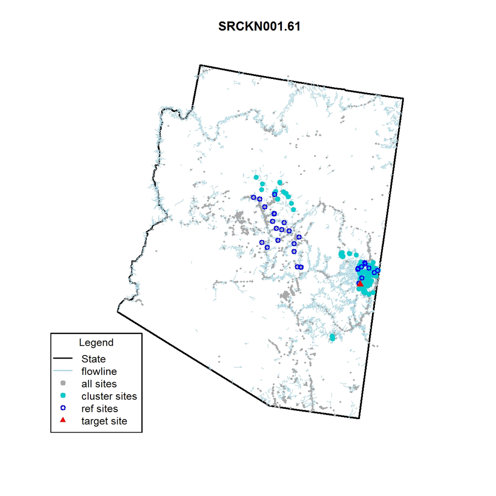

```r
TargetSiteID <- "SRCKN001.61"
myJPG <- paste0(TargetSiteID,".map.jpg")
fn.img <- file.path(getwd(), "Results", TargetSiteID, myJPG)
include_graphics(fn.img)
```

### getChemDataSubsets

Get chemical data subsets.

Requires the output of:

- getSiteInfo

The return is a summary list; ref.sites, ref.reaches, cluster.samps, chem.info , all.chems, cluster.chem, and site.chem.

```r
TargetSiteID <- "SRCKN001.61"
clustertype <- "5"
useLU <- FALSE

CurrentDir<-getwd()
myDir.Data <- paste(CurrentDir,"data/",sep="/")

# Run getSiteInfo
# data, example included with package
data.Stations.Info <- data_Sites
data.SampSummary   <- data_SampSummary
data.303d.ComID    <- data_303d
data.bmi.metrics   <- data_BMIMetrics
data.algae.metrics <- data_AlgMetrics
data.cluster       <- data_Cluster_Hi
data.mod           <- data_ReachMod
#
list.SiteSummary <- getSiteInfo(TargetSiteID, clustertype, useLU)

site.COMID <- list.SiteSummary$COMID
site.Clusters <- list.SiteSummary$ClustIDs

# data, example included with package
data.chem.raw <- data_Chem
data.chem.info <- data_ChemInfo

# Run getChemDataSubsets
list.data <- getChemDataSubsets(TargetSiteID, site.COMID, site.Clusters, clustertype, useLU)
```

The structure of the data is below.

```r
str(list.data)
```

```
## List of 7
##  $ ref.sites    : chr [1:30] "LCBEN002.57" "LCHAL010.20" "LCMAM002.05" "LCPAD001.30" ...
##  $ ref.reaches  : int [1:29] 20587030 20586742 20586710 20586804 20585206 20585250 20586666 20586780 22440682 22428278 ...
##  $ cluster.samps:'data.frame':   281 obs. of  2 variables:
##   ..$ StationID_Master: Factor w/ 441 levels "BWBOU007.83",..: 40 40 40 41 41 41 42 42 42 42 ...
##   ..$ ChemSampleID    : chr [1:281] "LCBEN002.57_2007-05-09" "LCBEN002.57_2006-11-15" "LCBEN002.57_2007-04-05" "LCBIL000.01_2010-03-09" ...
##  $ chem.info    :'data.frame':   41 obs. of  16 variables:
##   ..$ ConvertTo      : Factor w/ 278 levels "124Trichlorobenzene_uf_ug_L",..: 129 73 79 90 149 157 227 245 250 37 ...
##   ..$ ANALYSIS_TYPE  : Factor w/ 8 levels "CALCULATED","DISSOLVED",..: 8 8 8 8 1 8 8 8 8 2 ...
##   ..$ CHEMICAL_NAME  : Factor w/ 208 levels "1,2-DICHLOROBENZENE",..: 98 58 57 67 114 121 173 184 189 32 ...
##   ..$ FinalUnit      : Factor w/ 19 levels "CFS","CFU/100",..: 2 8 8 8 8 8 8 8 8 18 ...
##   ..$ StdParamName   : Factor w/ 278 levels "124Trichlorobenzene_uf_ug_L",..: 129 73 79 90 149 157 227 245 250 37 ...
##   ..$ Category       : Factor w/ 11 levels "Bacteria","Ions",..: 1 2 2 2 2 2 2 2 2 3 ...
##   ..$ LogTransf      : int [1:41] 1 1 1 1 1 1 1 1 1 1 ...
##   ..$ SSD            : int [1:41] 0 0 0 0 0 0 0 0 0 1 ...
##   ..$ SSTV           : Factor w/ 2 levels "","SpecCondTolVal": 1 1 1 1 1 1 1 1 1 1 ...
##   ..$ SensMin        : int [1:41] NA NA NA NA NA NA NA NA NA NA ...
##   ..$ SensMax        : int [1:41] NA NA NA NA NA NA NA NA NA NA ...
##   ..$ TolMin         : int [1:41] NA NA NA NA NA NA NA NA NA NA ...
##   ..$ TolMax         : int [1:41] NA NA NA NA NA NA NA NA NA NA ...
##   ..$ UseInStressorID: int [1:41] 1 1 1 1 1 1 1 1 1 1 ...
##   ..$ GroupNum       : num [1:41] 1 2 2 2 2 2 2 2 2 3 ...
##   ..$ GroupName      : Factor w/ 11 levels "Bacteria","Ions",..: 1 2 2 2 2 2 2 2 2 3 ...
##  $ all.chems    :List of 36
##  $ ChemSampleID                  : chr [1:1477] "BWCBW009.00_2008-12-16" "BWCBW009.00_2008-12-19" "BWCBW009.00_2008-12-26" "BWCBW009.00_2010-01-23" ...
##  $ Arsenic_inorg_f_ug_L          : num [1:1477] NA NA NA NA NA NA NA NA NA 2.1 ...
##  $ Arsenic_inorg_uf_ug_L         : num [1:1477] NA NA NA 6.5 NA NA NA NA NA 2.7 ...
##  $ CaCO3_uf_mg_L                 : num [1:1477] NaN NaN NaN NaN NaN 210 110 77 73 120 ...
##  $ Calcium_uf_mg_L               : num [1:1477] 390 500 440 260 NaN 240 21 15 13 20 ...
##  $ Carbon_f_mg_L                 : num [1:1477] NaN NaN NaN NaN NaN NaN NaN NaN NaN NaN ...
##  $ Carbon_uf_mg_L                : num [1:1477] NaN NaN NaN NaN NaN NaN NaN NaN NaN NaN ...
##  $ Chloride_uf_mg_L              : num [1:1477] NaN NaN NaN NaN NaN 54 NA NA NA 14 ...
##  $ Copper_uf_ug_L                : num [1:1477] 680 96 220 518 0.92 170 NA NA NA NA ...
##  $ CrossSectionalArea_calc       : num [1:1477] NaN NaN NaN NaN NaN NaN NaN 0.58 NaN 2.35 ...
##  $ Depth_ft                      : num [1:1477] NaN NaN NaN NaN NaN NaN 0.15 0.23 0.25 0.39 ...
##  $ DO_f_%                        : num [1:1477] 92.3 NaN NaN NaN NaN ...
##  $ DO_f_mg_L                     : num [1:1477] 10.2 NaN NaN NaN NaN ...
##  $ Ecoli_uf_CFU_100              : num [1:1477] NaN NaN NaN NaN NaN NaN 5 NA NA 6 ...
##  $ Flow_cfs                      : num [1:1477] 0.01 0.05 0.035 0.05 0.001 0.001 0.121 0.22 0.68 0.53 ...
##  $ Flow_ft_sec                   : num [1:1477] NaN NaN NaN NaN NaN NaN 0.5 0.27 0.8 0.19 ...
```

[output cut: 94 more lines]

```
##  $ Sodium_uf_mg_L                : num [1:8] 3.1 3.2 3 76.95 4.05 ...
##  $ SpecCond_umhos_cm             : num [1:8] 91.8 90.5 80 271.3 196.3 ...
##  $ StreamWidth_ft                : num [1:8] 10.5 2.25 1.5 NaN 4.9 6.1 1.8 2.5
##  $ Sulfate_uf_mg_L               : num [1:8] 3.4 2.7 3.4 12.5 4.7 9.4 6 6.2
##  $ TDS_f_mg_L                    : num [1:8] 72.7 65.5 57 167 124.3 ...
##  $ Temp_degC                     : num [1:8] 22 12.1 19.7 27.2 12.8 ...
##  $ TSS_susp_mg_L                 : num [1:8] 1.06 0.936 NaN 173 NaN NaN NaN 3.3
##  $ Turbidity_NTU                 : num [1:8] 0.84 1.2 0.92 268 0.54 1.04 2.22 1.65
##  - attr(*, "row.names")= int [1:8] 1 2 3 4 5 6 7 8
##  - attr(*, "idvars")= chr "ChemSampleID"
##  - attr(*, "rdimnames")=List of 2
##   ..$ :'data.frame': 8 obs. of  1 variable:
##   .. ..$ ChemSampleID: chr [1:8] "SRCKN001.61_2010-09-02" "SRCKN001.61_2010-10-11" "SRCKN001.61_2011-05-05" "SRCKN001.61_2011-08-17" ...
##   ..$ :'data.frame': 35 obs. of  1 variable:
##   .. ..$ ConvertTo: Factor w/ 278 levels "124Trichlorobenzene_uf_ug_L",..: 37 39 73 79 82 83 90 106 108 113 ...
```

### getStressorList

Box plots of each stressor, grouped by category.

Requires the output of:

- getSiteInfo
- getChemDataSubsets

Returns a jpeg in the “Results” subdirectory of the working directory with box plots. Also returns a list of stressors; stressors and site.stressor.pctrank.

The plots are named as SiteID.boxes.category.jpg, e.g., SRCKN001.61.boxes.Nutrients.jpg.

```r
TargetSiteID <- "SRCKN001.61"
clustertype <- "5"
useLU <- FALSE

CurrentDir<-getwd()
myDir.Data <- paste(CurrentDir,"data/",sep="/")

# datasets getSiteInfo
# data, example included with package
data.Stations.Info <- data_Sites
data.SampSummary   <- data_SampSummary
data.303d.ComID    <- data_303d
data.bmi.metrics   <- data_BMIMetrics
data.algae.metrics <- data_AlgMetrics
data.cluster       <- data_Cluster_Hi
data.mod           <- data_ReachMod
#
# Run getSiteInfo
list.SiteSummary <- getSiteInfo(TargetSiteID, clustertype, useLU)

# datasets getChemDataSubsets
site.COMID <- list.SiteSummary$COMID
site.Clusters <- list.SiteSummary$ClustIDs

# data import, example
# data.chem.raw <- read.delim(paste(myDir.Data,"data.chem.raw.tab",sep=""),na.strings = c(""," "))
# data.chem.info <- read.delim(paste(myDir.Data,"data.chem.info.tab",sep=""))

# data, example included with package
data.chem.raw <- data_Chem
data.chem.info <- data_ChemInfo

# Run getChemDataSubsets
list.data <- getChemDataSubsets(TargetSiteID, site.COMID, site.Clusters, clustertype, useLU)

# datasets getStressorList
chem.info <- list.data$chem.info
cluster.chem <- list.data$cluster.chem
cluster.samps <- list.data$cluster.samps
ref.sites <- list.data$ref.sites
site.chem <- list.data$site.chem

# set cutoff for possible stressor identification
probsLow <- 0.10
probsHigh <- 0.90

# Run getStressorList
list.stressors <- getStressorList(TargetSiteID, site.Clusters, chem.info, cluster.chem
                                 , cluster.samps, ref.sites, site.chem
                                 , probsHigh, probsLow)
```

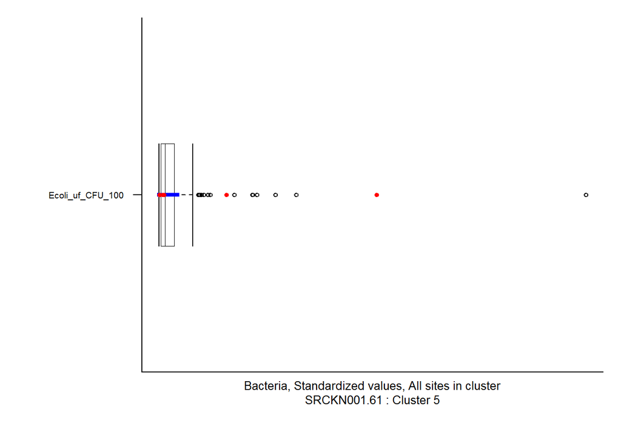

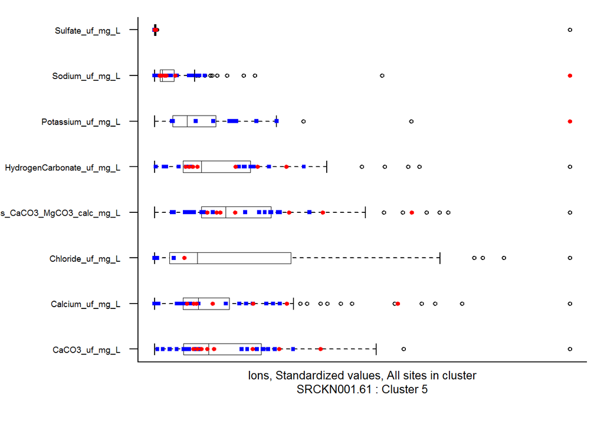

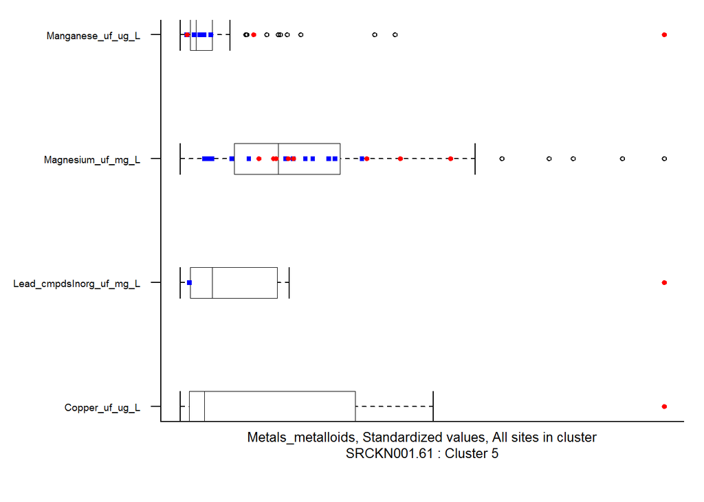

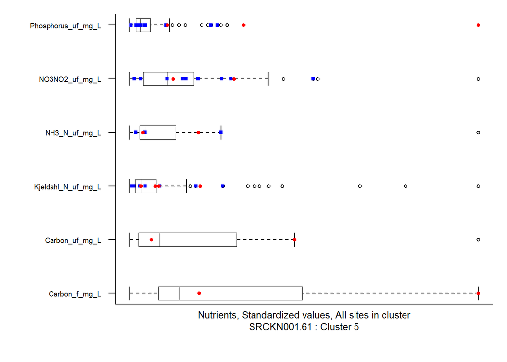

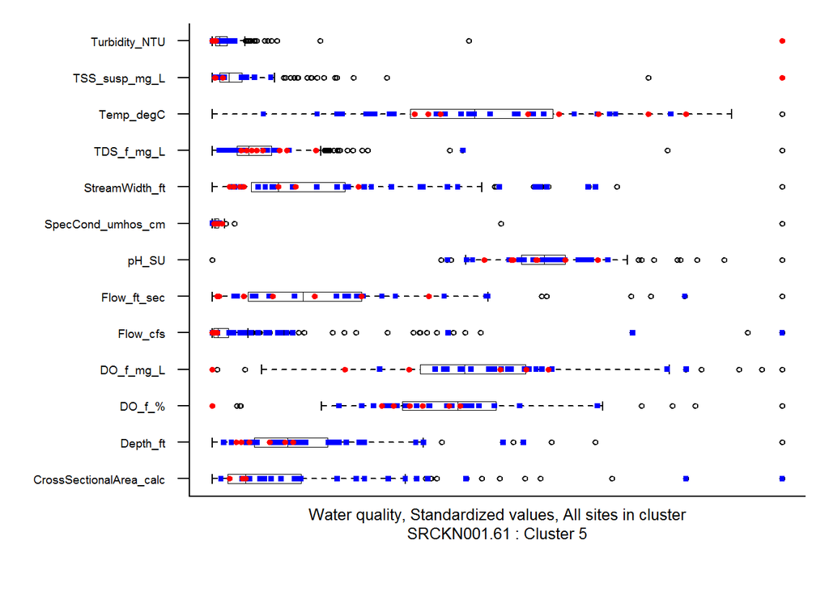

The structure of the returned data is below.

```r
str(list.stressors)
```

```
## List of 3
##  $ stressors            : chr [1:24] "none" "Arsenic_inorg_uf_ug_L" "CaCO3_uf_mg_L" "Calcium_uf_mg_L" ...
##  $ site.stressor.pctrank:'data.frame':   8 obs. of  37 variables:
##   ..$ StationID_Master              : Factor w/ 441 levels "BWBOU007.83",..: 244 244 244 244 244 244 244 244
##   ..$ ChemSampleID                  : Factor w/ 281 levels "LCBEN002.57_2006-11-15",..: 174 175 176 177 178 179 180 181
##   ..$ Arsenic_inorg_f_ug_L          : num [1:8] NA NA NA NA NA NA NA NA
##   ..$ Arsenic_inorg_uf_ug_L         : num [1:8] NA NA NA 1 NA NA NA NA
##   ..$ CaCO3_uf_mg_L                 : num [1:8] 0.379 0.427 0.347 0.935 0.815 ...
##   ..$ Calcium_uf_mg_L               : num [1:8] 0.463 0.433 0.315 0.98 0.926 ...
##   ..$ Carbon_f_mg_L                 : num [1:8] NA NA NA 1 0.591 ...
##   ..$ Carbon_uf_mg_L                : num [1:8] NA NA NA 0.955 0.409 ...
##   ..$ Chloride_uf_mg_L              : num [1:8] NA NA NA NA NA ...
##   ..$ Copper_uf_ug_L                : num [1:8] NA NA NA 1 NA NA NA NA
##   ..$ CrossSectionalArea_calc       : num [1:8] 0.477 NA NA NA 0.291 ...
##   ..$ Depth_ft                      : num [1:8] 0.138 0.476 0.343 NA 0.21 ...
##   ..$ DO_f_%                        : num [1:8] 0.443 0.286 0.204 NA 0.325 ...
##   ..$ DO_f_mg_L                     : num [1:8] 0.2 0.753 0.753 NA 0.816 ...
##   ..$ Ecoli_uf_CFU_100              : num [1:8] 0.449 0.019 0.019 0.994 0.38 ...
##   ..$ Flow_cfs                      : num [1:8] 0.3346 0.4779 0.2132 0 0.0478 ...
##   ..$ Flow_ft_sec                   : num [1:8] 0.1863 0.8529 0.7451 NA 0.0294 ...
##   ..$ Hardness_CaCO3_MgCO3_calc_mg_L: num [1:8] 0.455 0.395 0.323 0.97 0.91 ...
##   ..$ HydrogenCarbonate_uf_mg_L     : num [1:8] 0.331 0.387 0.266 0.895 0.774 ...
##   ..$ Kjeldahl_N_uf_mg_L            : num [1:8] NA NA NA 0.922 NA ...
##   ..$ Lead_cmpdsInorg_uf_mg_L       : num [1:8] NA NA NA 1 NA NA NA NA
##   ..$ Magnesium_uf_mg_L             : num [1:8] 0.47 0.443 0.369 0.933 0.879 ...
##   ..$ Manganese_uf_ug_L             : num [1:8] NA NA NA 1 0.176 ...
##   ..$ Mercury_elemental_uf_mg_L     : num [1:8] NA NA NA NA NA NA NA NA
##   ..$ NH3_N_uf_mg_L                 : num [1:8] 0.258 0.258 NA 0.871 NA ...
##   ..$ NO3NO2_uf_mg_L                : num [1:8] NA NA NA 0.571 NA ...
##   ..$ pH_SU                         : num [1:8] 0.418 0.182 0.418 0.742 0.931 ...
##   ..$ Phosphorus_uf_mg_L            : num [1:8] NA NA NA 1 0.877 ...
##   ..$ Potassium_uf_mg_L             : num [1:8] NA NA NA 1 NA NA NA NA
##   ..$ Sodium_uf_mg_L                : num [1:8] 0.383 0.447 0.301 1 0.655 ...
##   ..$ SpecCond_umhos_cm             : num [1:8] 0.467 0.46 0.372 0.927 0.796 ...
##   ..$ StreamWidth_ft                : num [1:8] 0.7725 0.1659 0.0616 NA 0.4976 ...
##   ..$ Sulfate_uf_mg_L               : num [1:8] 0.309 0.23 0.309 0.974 0.545 ...
##   ..$ TDS_f_mg_L                    : num [1:8] 0.569 0.476 0.35 0.907 0.833 ...
##   ..$ Temp_degC                     : num [1:8] 0.873 0.315 0.772 0.982 0.359 ...
##   ..$ TSS_susp_mg_L                 : num [1:8] 0.0585 0.0117 NA 1 NA ...
##   ..$ Turbidity_NTU                 : num [1:8] 0.0576 0.1276 0.0658 1 0.0123 ...
##  $ stressors_LogTransf  : num [1:24] 0 1 1 1 1 1 1 1 1 1 ...
```

One text file is created.

- SRCKN001.61.chem.pctrank.txt

And plots are created and saved per stressor group. The “nutrient” plot is shown below.

```r
TargetSiteID <- "SRCKN001.61"
# filename
fn.pctrank <- file.path(getwd(), "Results", TargetSiteID
                        , paste0(TargetSiteID, ".chem.pctrank.txt"))
# read
df.pctrank <- read.delim(fn.pctrank)
# Structure
str(df.pctrank)
```

```
## 'data.frame':    281 obs. of  37 variables:
##  $ StationID_Master              : Factor w/ 66 levels "LCBEN002.57",..: 1 1 1 2 2 2 3 3 3 3 ...
##  $ ChemSampleID                  : Factor w/ 281 levels "LCBEN002.57_2006-11-15",..: 1 2 3 4 5 6 7 8 9 10 ...
##  $ Arsenic_inorg_f_ug_L          : num  NA NA NA 1 NA ...
##  $ Arsenic_inorg_uf_ug_L         : num  NA NA NA 0.833 NA ...
##  $ CaCO3_uf_mg_L                 : num  0.863 0.677 0.653 0.887 0.694 ...
##  $ Calcium_uf_mg_L               : num  0.906 0.768 0.724 0.867 0.788 ...
##  $ Carbon_f_mg_L                 : num  NA NA NA NA NA NA NA NA NA NA ...
##  $ Carbon_uf_mg_L                : num  NA NA NA NA NA NA NA NA NA NA ...
##  $ Chloride_uf_mg_L              : num  NA NA NA 0.933 0.764 ...
##  $ Copper_uf_ug_L                : num  NA NA NA NA NA NA NA NA NA NA ...
##  $ CrossSectionalArea_calc       : num  NA 0.105 NA 0.547 NA ...
##  $ Depth_ft                      : num  0.0286 0.2333 0.2571 0.5381 1 ...
##  $ DO_f_.                        : num  0.2706 0.1647 0.0941 0.9451 0.1765 ...
##  $ DO_f_mg_L                     : num  0.702 0.533 0.749 0.584 0.396 ...
```

[output cut: 23 more lines]

```r
# create table
# first 6 rows and columns
kable(df.pctrank[1:6, 1:6], caption="partial table")
```

partial table

| StationID_Master | ChemSampleID | Arsenic_inorg_f_ug_L | Arsenic_inorg_uf_ug_L | CaCO3_uf_mg_L | Calcium_uf_mg_L |
| --- | --- | --- | --- | --- | --- |
| LCBEN002.57 | LCBEN002.57_2006-11-15 | NA | NA | 0.8629032 | 0.9064039 |
| LCBEN002.57 | LCBEN002.57_2007-04-05 | NA | NA | 0.6774194 | 0.7684729 |
| LCBEN002.57 | LCBEN002.57_2007-05-09 | NA | NA | 0.6532258 | 0.7241379 |
| LCBIL000.01 | LCBIL000.01_2009-09-22 | 1.0000000 | 0.8333333 | 0.8870968 | 0.8669951 |
| LCBIL000.01 | LCBIL000.01_2010-03-09 | NA | NA | 0.6935484 | 0.7881773 |
| LCBIL000.01 | LCBIL000.01_2010-05-06 | 0.5714286 | 0.3333333 | 0.8870968 | 0.9507389 |

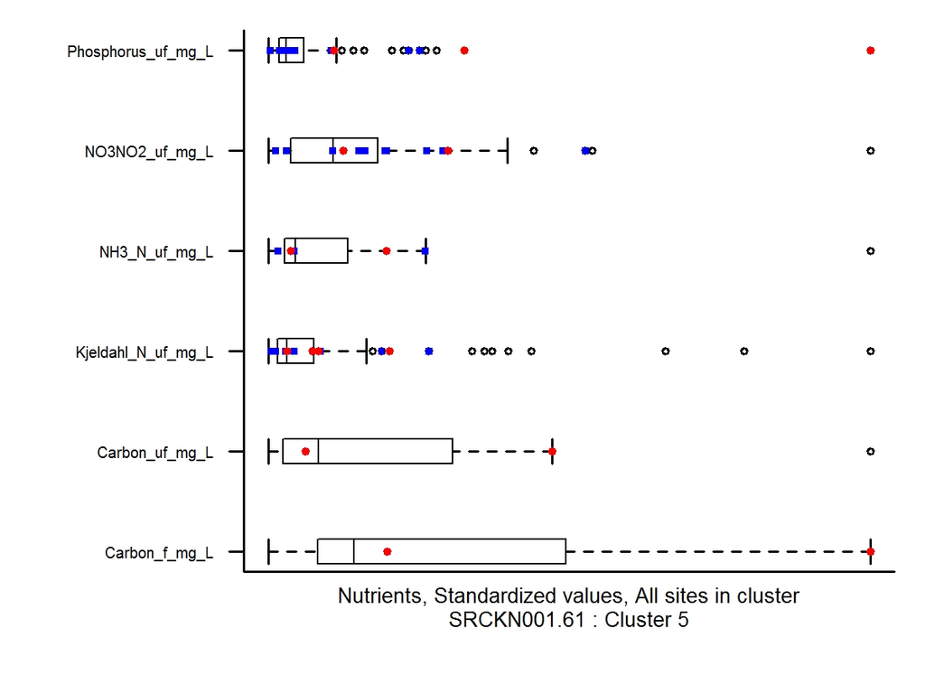

```r
# box plot
myJPG <- paste0(TargetSiteID,".boxes.Nutrients.jpg")
fn.img <- file.path(getwd(), "Results", TargetSiteID, myJPG)
include_graphics(fn.img)
```

- The stressor categories are:
  - Bacteria
  - Ions
  - Metals_metalloids
  - Nutrients
  - Water quality
- The data ploted is only **within** cluster data (denoted on the x-axis).
- Stressors are on the y-axis and correspond to column names in the data.
- The x-axis is percent rank (0-1).
- Box and whisker plots have the following attributes:
  - boxes are 25th and 75th percentiles
  - box line is 50th percentile (median)
  - whiskers are non-outlier min and max
  - outliers (black open circles)
  - Outliers are ouside of 1.5*IQR (Interquartile Range, 75th-25th percentile)
  - Cluster reference sites (blue closed squares)
  - Test site data (red closed circles)

### getClusterInfo

Summary cluster information.

The return is a jpeg in the “Results” subdirectory of the working directory.  
The plots are names with SiteID.cluster.parameter.jpg, e.g., SRCKN001.61.cluster.ElevWs.jpg.

In this case example 95 plots are created.

```r
TargetSiteID <- "SRCKN001.61"
clustertype <- "5"
useLU <- FALSE

CurrentDir<-getwd()
myDir.Data <- paste(CurrentDir,"data/",sep="/")

# datasets getSiteInfo
# data, example included with package
data.Stations.Info <- data_Sites
data.SampSummary   <- data_SampSummary
data.303d.ComID    <- data_303d
data.bmi.metrics   <- data_BMIMetrics
data.algae.metrics <- data_AlgMetrics
data.cluster       <- data_Cluster_Hi
data.mod           <- data_ReachMod

# Run getSiteInfo
list.SiteSummary <- getSiteInfo(TargetSiteID, clustertype, useLU)

# datasets getChemDataSubsets
site.COMID <- list.SiteSummary$COMID
site.Clusters <- list.SiteSummary$ClustIDs
# data, example included with package
data.chem.raw <- data_Chem
data.chem.info <- data_ChemInfo

#
# Run getChemDataSubsets
list.data <- getChemDataSubsets(TargetSiteID, site.COMID, site.Clusters, clustertype, useLU)

# datasets getClusterInfo
ref.reaches <- list.data$ref.reaches
refSiteCOMIDs <- list.data$ref.reaches

# Run getClusterInfo
getClusterInfo(site.COMID, clustertype, site.Clusters, ref.reaches, useLU)
```

```
## [1] "Processing item, 1/95; Al2O3Cat"
```

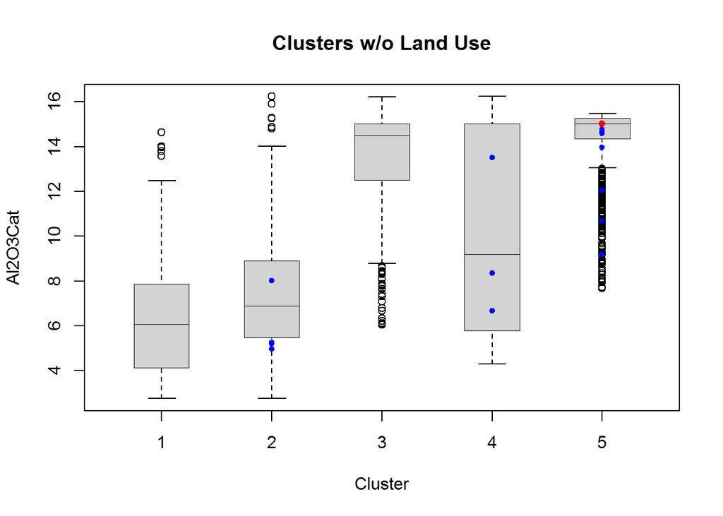

```
## [1] "Processing item, 2/95; Al2O3Ws"
```

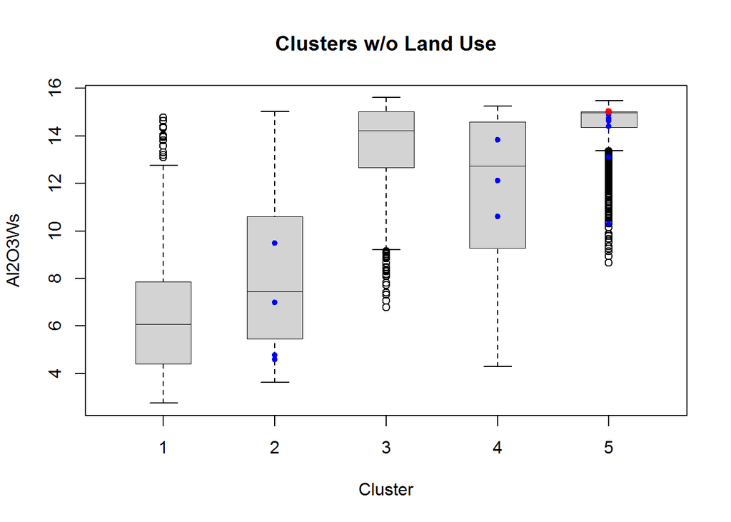

```
## [1] "Processing item, 3/95; BFICat"
```

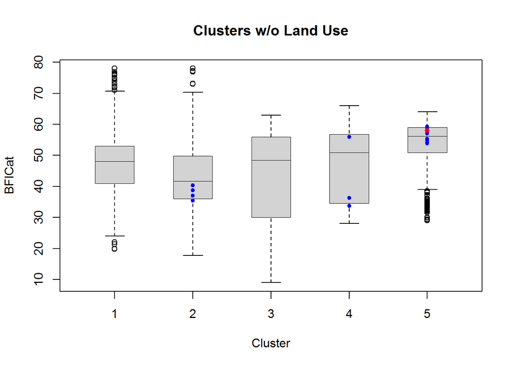

```
## [1] "Processing item, 4/95; BFIWs"
```

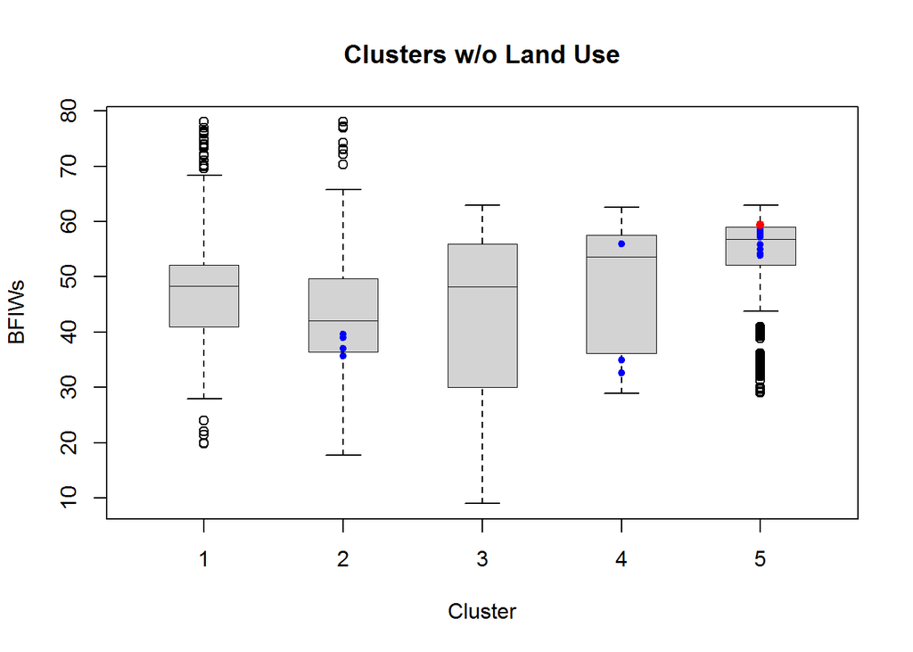

```
## [1] "Processing item, 5/95; CompStrgthCat"
```

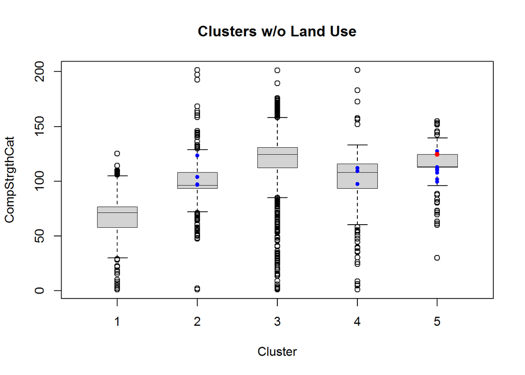

```
## [1] "Processing item, 6/95; CompStrgthWs"
```

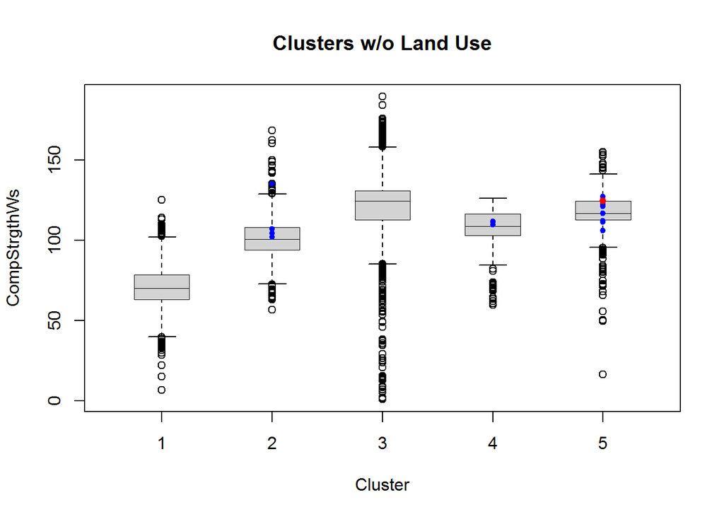

```
## [1] "Processing item, 7/95; KffactCat"
```

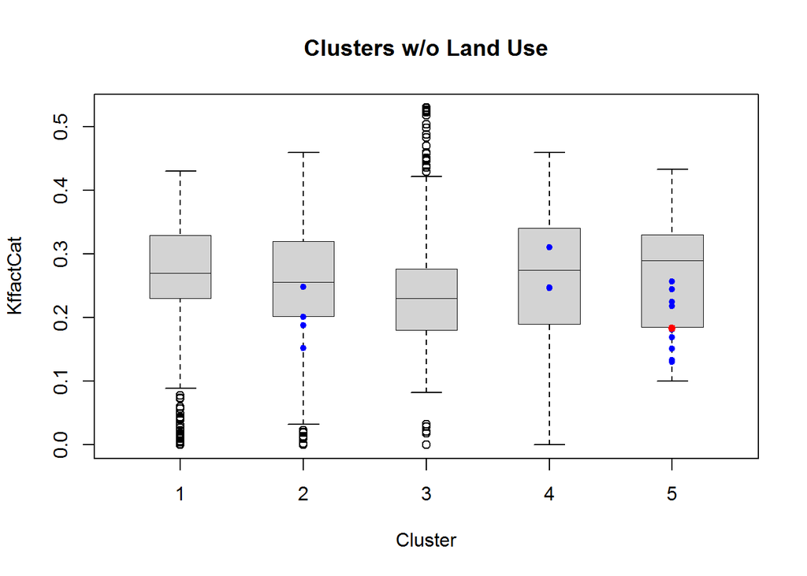

```
## [1] "Processing item, 8/95; KffactWs"
```

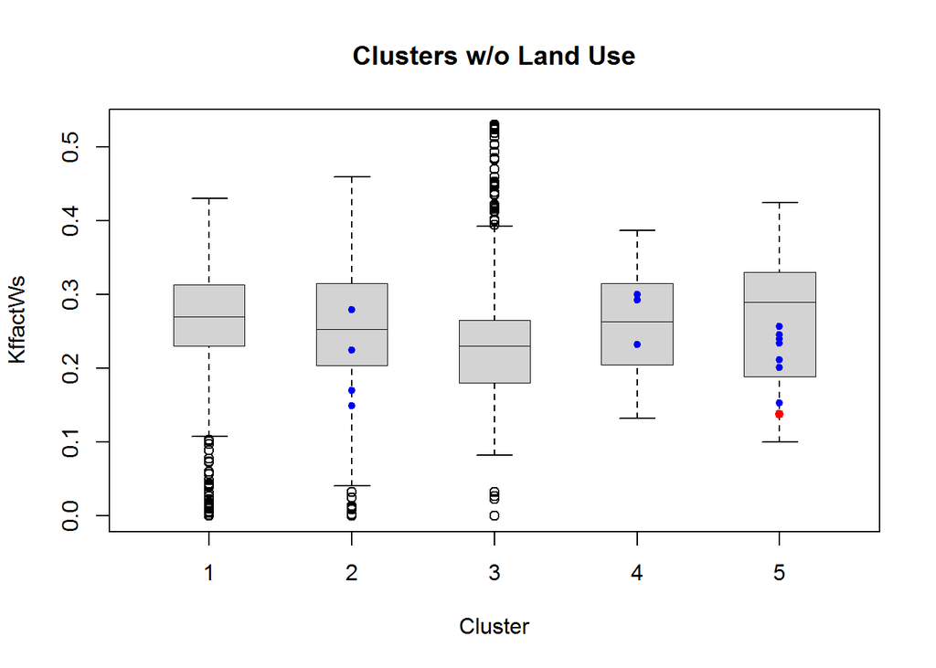

```
## [1] "Processing item, 9/95; Na2OWs"
```

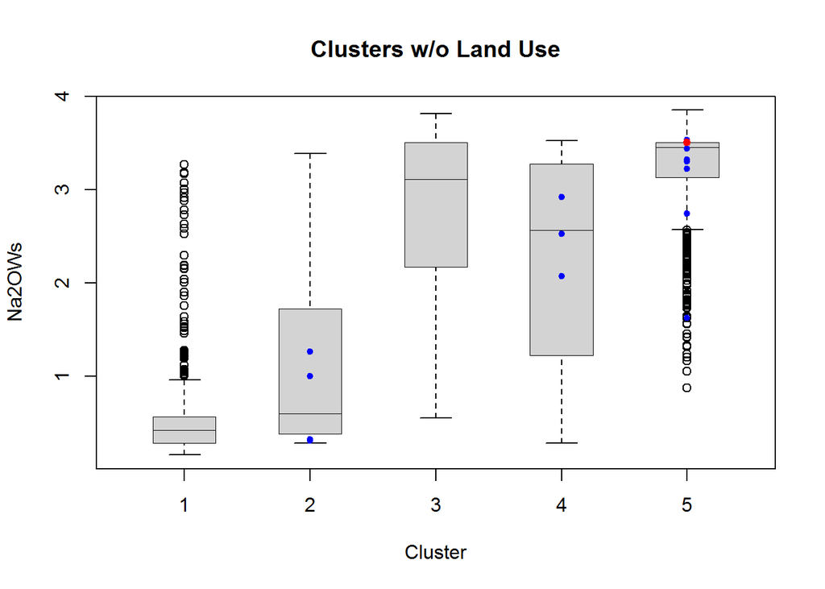

```
## [1] "Processing item, 10/95; PctSilicicWs"
```

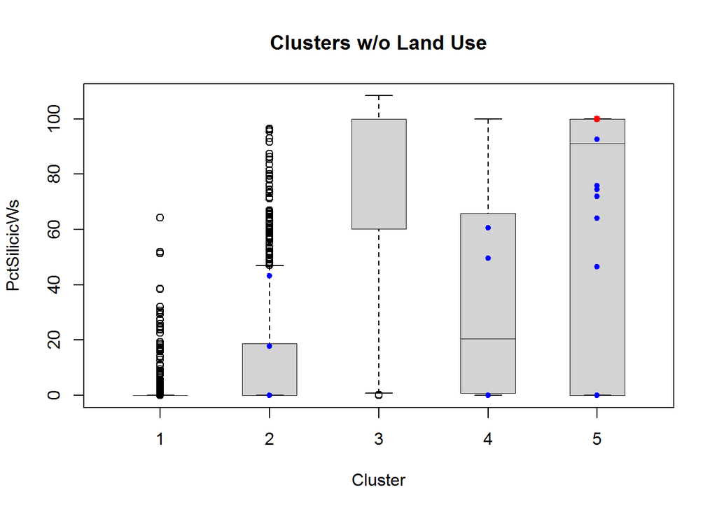

```
## [1] "Processing item, 11/95; SandCat"
```

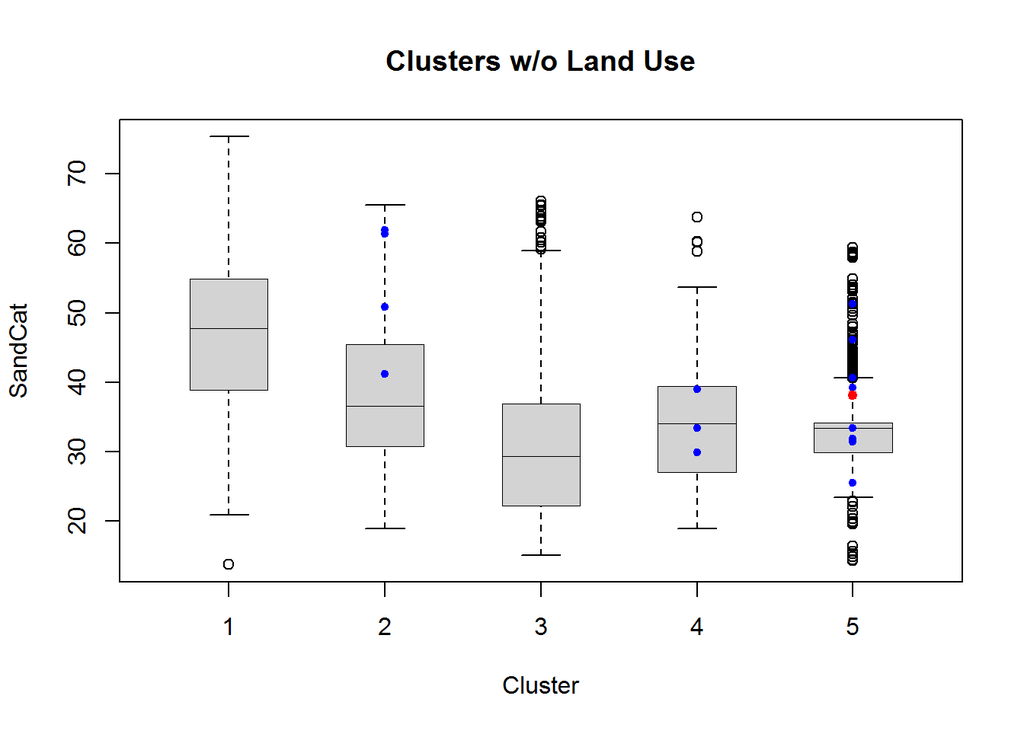

```
## [1] "Processing item, 12/95; SandWs"
```

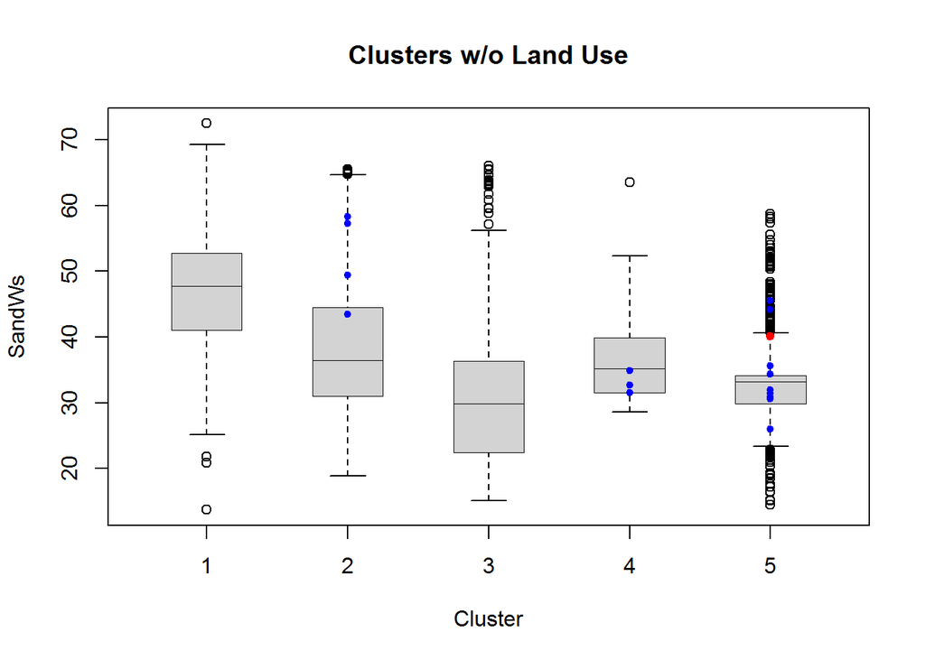

```
## [1] "Processing item, 13/95; SiO2Cat"
```

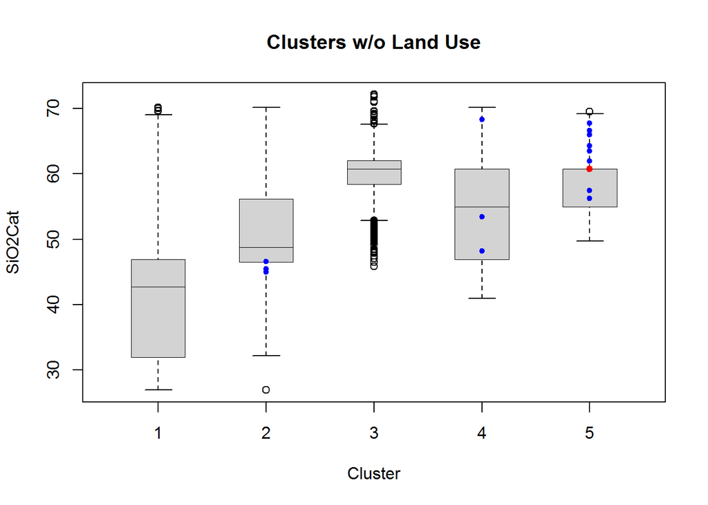

```
## [1] "Processing item, 14/95; SiO2Ws"
```

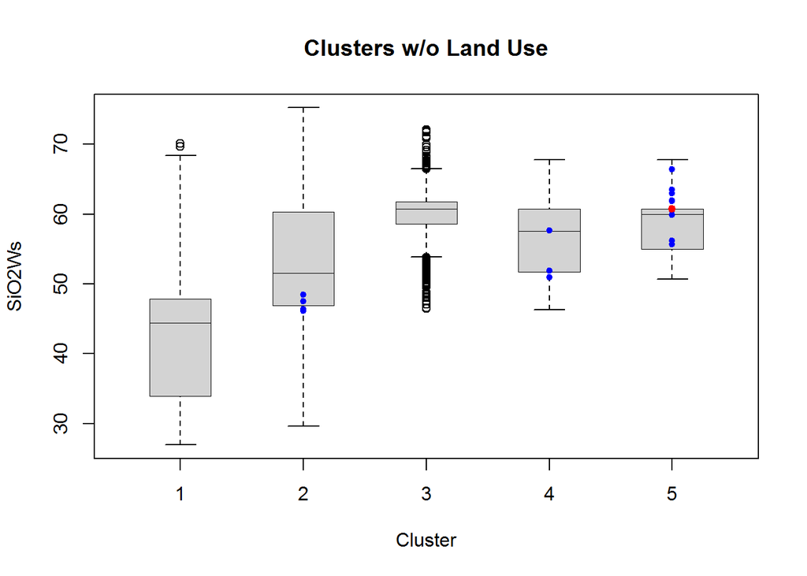

```
## [1] "Processing item, 15/95; Tmax8110Cat"
```

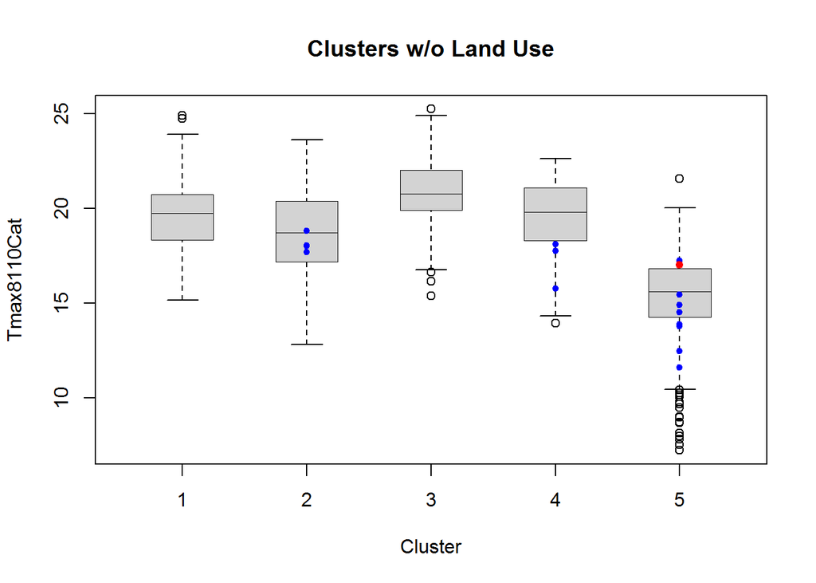

```
## [1] "Processing item, 16/95; Tmax8110Ws"
```

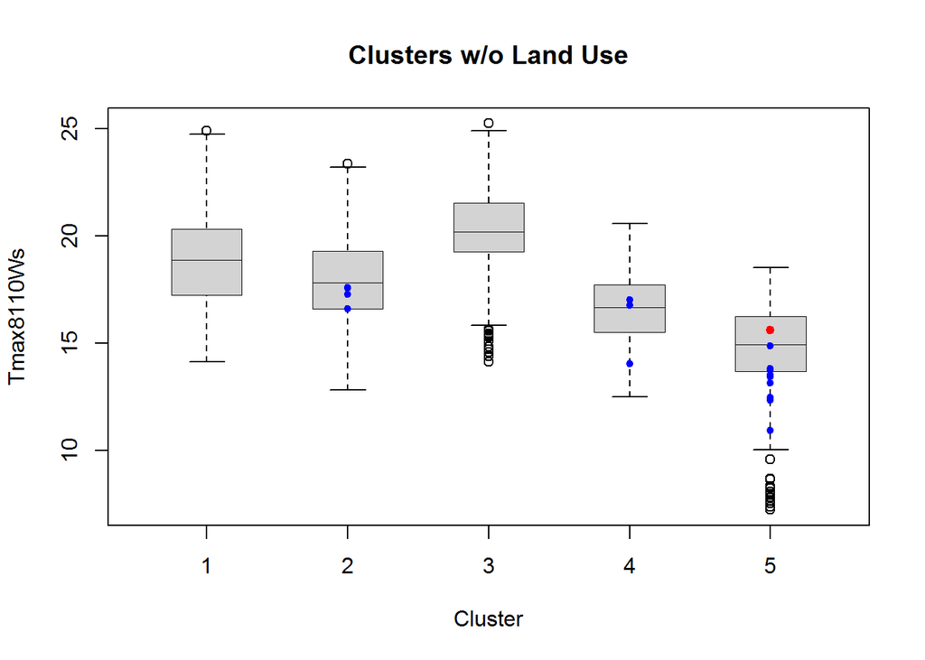

```
## [1] "Processing item, 17/95; Tmean08Cat"
```

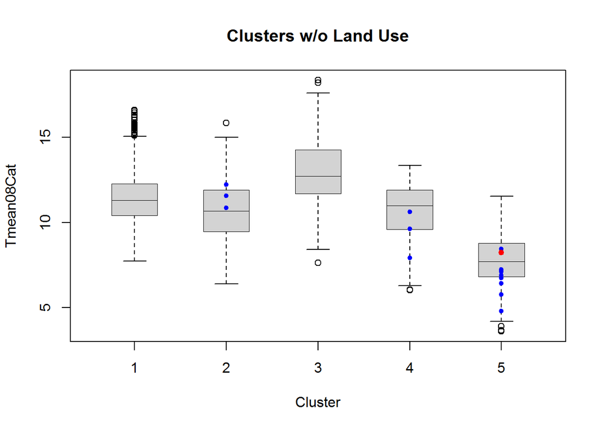

```
## [1] "Processing item, 18/95; Tmean08Ws"
```

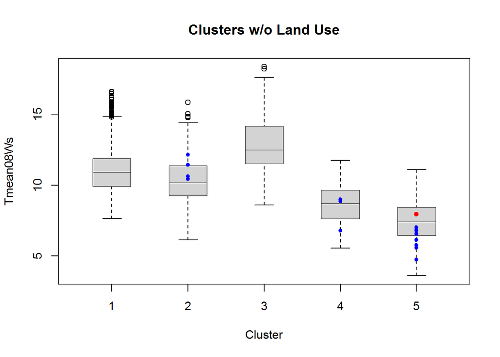

```
## [1] "Processing item, 19/95; Tmean09Cat"
```

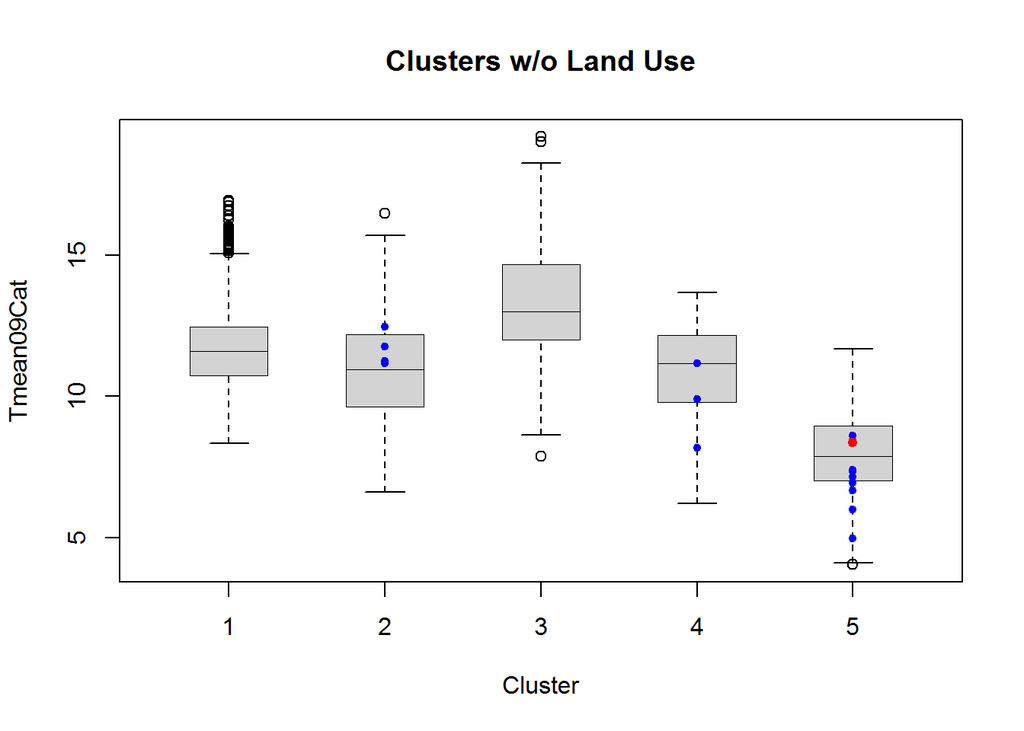

```
## [1] "Processing item, 20/95; Tmean09Ws"
```

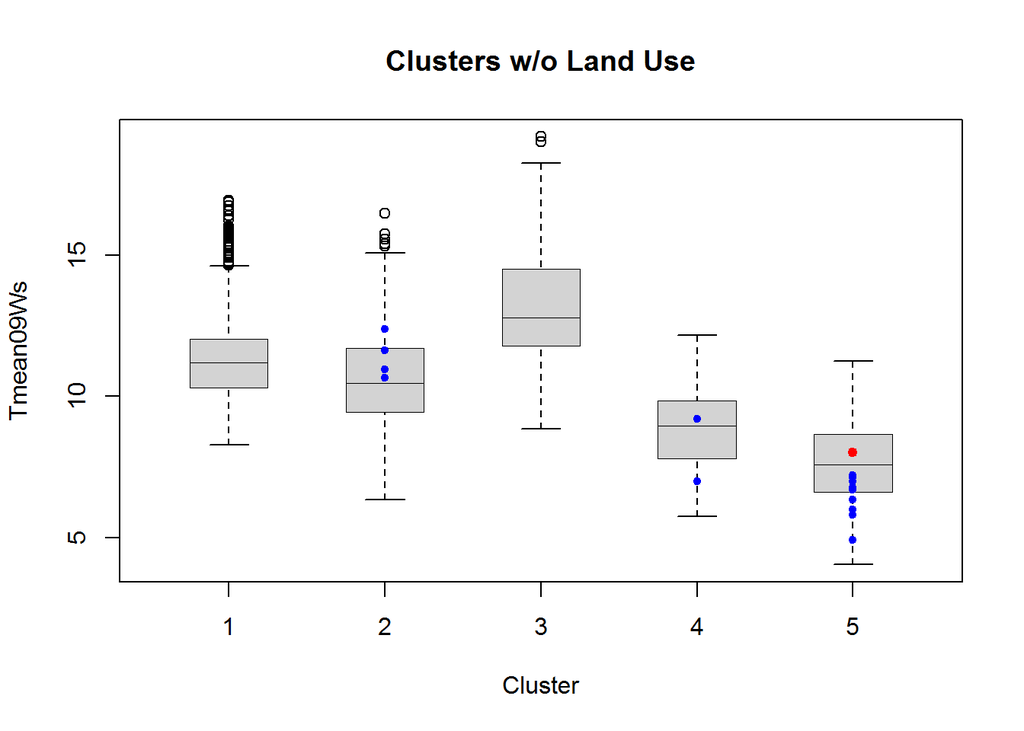

```
## [1] "Processing item, 21/95; Tmean8110Cat"
```

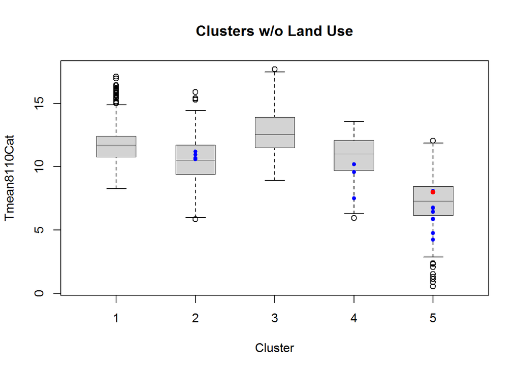

```
## [1] "Processing item, 22/95; Tmean8110Ws"
```

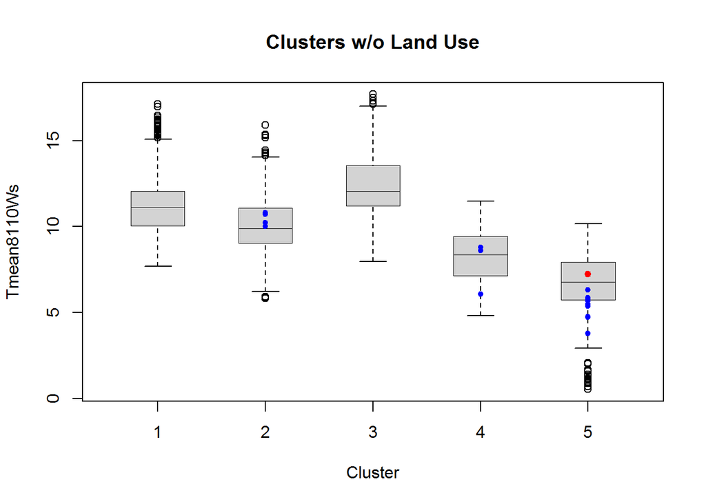

```
## [1] "Processing item, 23/95; Tmin8110Cat"
```

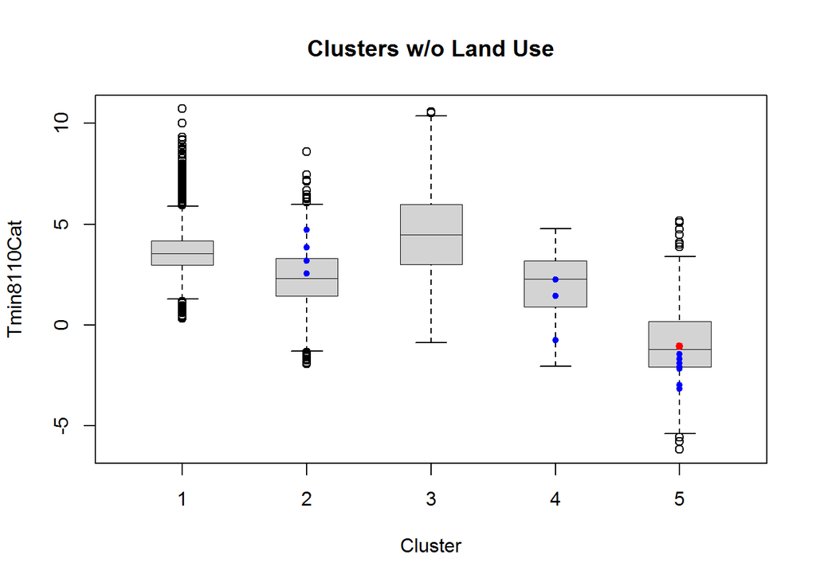

```
## [1] "Processing item, 24/95; Tmin8110Ws"
```

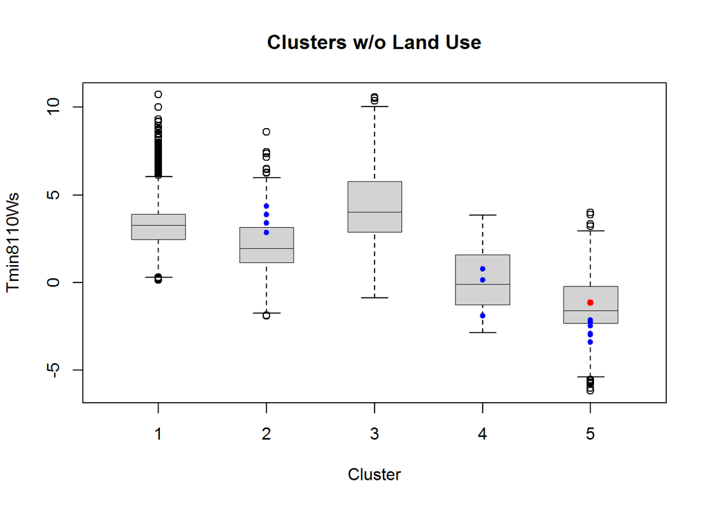